# JLC 445/696 Final Project Template

04 December 2024

- 1. Research Question
- 2. Data
- 3. Methods
- 4. Findings
- 5. Visuals
  - 1-2 Graphs
  - 1-2 Maps

Libraries needed for this project (showing this code is optional):

```r
library(tidyverse)
library(leaflet)
library(sf)
library(tigris)
library(zoo)
library(aTSA)
library(tseries)
library(forecast)
```

# 1. Research Question

# 2. Data

(Showing the code here is optional)

Getting the data:

```r
url <- "https://opendata.dc.gov/datasets/DCGIS::crime-incidents-in-"
years <- c(2008:2024)
full.urls <- paste0(url, years, ".csv")
dc.data <- data.frame()

for(file in full.urls) {
  tmp.data <- read.csv(file, stringsAsFactors = FALSE)
  dc.data <- rbind(tmp.data, dc.data)
}
```

Cleaning the data:

```r
dc.data <- separate(dc.data, REPORT_DAT, into = c("DATE", "TIME"), sep = " ")
dc.data$DATE <- as.Date(dc.data$DATE, format = "%Y/%m/%d")
dc.data$YEAR <- substr(dc.data$DATE, 0, 4)
dc.data$MONTH <- month(dc.data$DATE)
dc.data$MONTHS <- months(dc.data$DATE)
dc.data$DAY <- day(dc.data$DATE)
dc.data$DOW <- weekdays(dc.data$DATE)
dc.data$HOUR <- substr(dc.data$TIME, 0, 2)
```

Filtering the data:

```r
group <- c("MOTOR VEHICLE THEFT")
dc.subset <- dc.data %>% filter(dc.data$OFFENSE %in% group)
```

# 3. Methods

(Pick and choose what code you show here; recommend cleaning to only have code for the data you use; meaning don’t include ‘stationary2’ and ‘stationary3’ if you use ‘stationary1’)

Create a time series dataset for count of crimes per day:

```r
crime <- dc.subset %>%
  group_by(DATE) %>%
  summarise(CRIME.COUNT = n())

crime <- crime %>%
  complete(DATE = seq.Date(min(DATE), max(DATE), by = "day")) %>%
  mutate(WEEKDAY = lubridate::wday(DATE, label = T, week_start = 1),
         MONTH = lubridate::month(DATE, label = T, abbr = F),
         WEEK = isoweek(DATE),
         DAY = day(DATE),
         YEAR = year(DATE))
crime <- replace(crime, is.na(crime), 0)

cleaned.crime <- zoo(crime$CRIME.COUNT,
                       seq(from = as.Date(min(crime$DATE)),
                           to = as.Date(max(crime$DATE)-1), by = 1))
```

Create stationary, differenced datasets:

```r
stationary1 <- diff(cleaned.crime, differences = 1)
stationary2 <- diff(cleaned.crime, differences = 2)
stationary3 <- diff(cleaned.crime, differences = 3)
```

Visualize their plots:

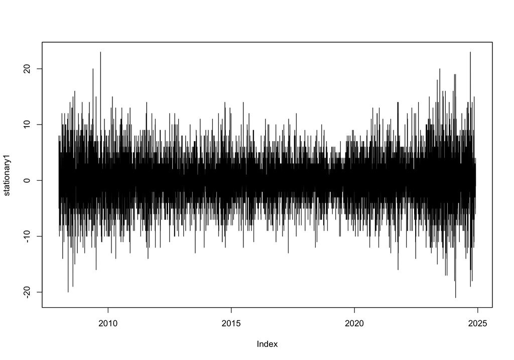

```r
plot(stationary1)
```

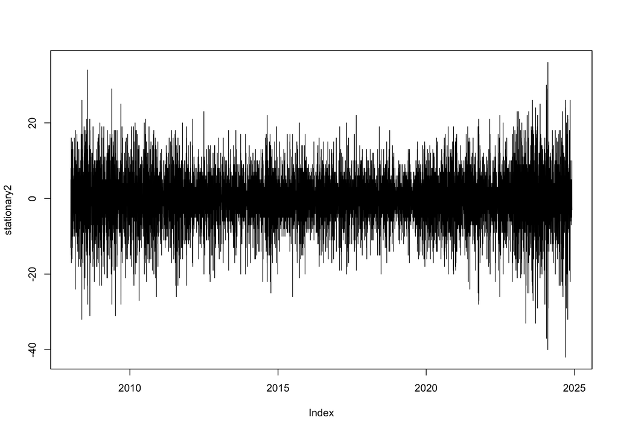

```r
plot(stationary2)
```

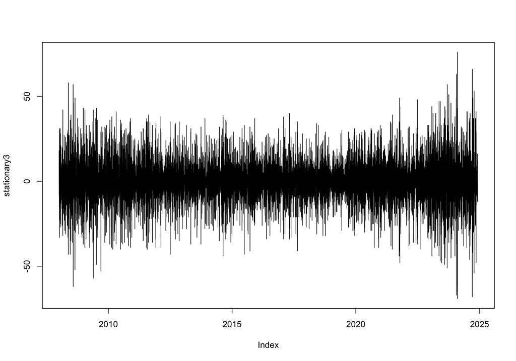

```r
plot(stationary3)
```

Run ADF tests for the original data, and the differenced data:

```r
adf.test(as.matrix(cleaned.crime))
```

```
##
##  Augmented Dickey-Fuller Test
##
## data:  as.matrix(cleaned.crime)
## Dickey-Fuller = -4.2188, Lag order = 18, p-value = 0.01
## alternative hypothesis: stationary
```

```r
adf.test(as.matrix(stationary1))
```

```
##
##  Augmented Dickey-Fuller Test
##
## data:  as.matrix(stationary1)
## Dickey-Fuller = -30.506, Lag order = 18, p-value = 0.01
## alternative hypothesis: stationary
```

```r
adf.test(as.matrix(stationary2))
```

```
##
##  Augmented Dickey-Fuller Test
##
## data:  as.matrix(stationary2)
## Dickey-Fuller = -38.749, Lag order = 18, p-value = 0.01
## alternative hypothesis: stationary
```

```r
adf.test(as.matrix(stationary3))
```

```
##
##  Augmented Dickey-Fuller Test
##
## data:  as.matrix(stationary3)
## Dickey-Fuller = -46.089, Lag order = 18, p-value = 0.01
## alternative hypothesis: stationary
```

Choose the best fitting dataset.

Determine **p** value:

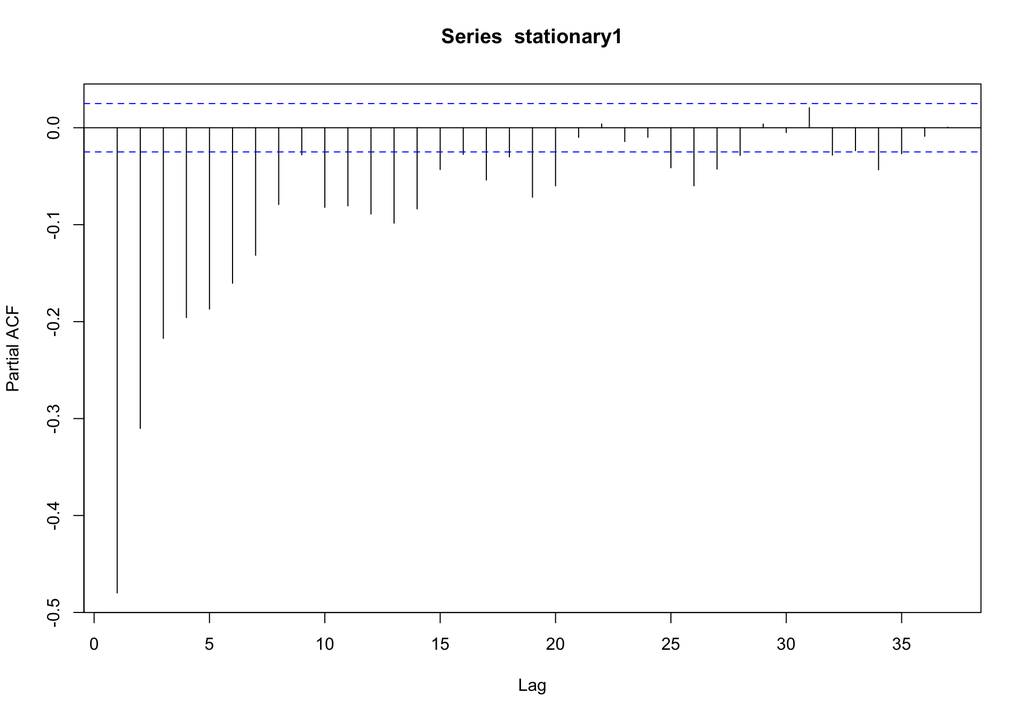

```r
pacf(stationary1)
```

```r
pacf(stationary1, pl=FALSE)
```

```
##
## Partial autocorrelations of series 'stationary1', by lag
##
##      1      2      3      4      5      6      7      8      9     10     11
## -0.480 -0.310 -0.217 -0.196 -0.187 -0.160 -0.132 -0.079 -0.028 -0.082 -0.081
##     12     13     14     15     16     17     18     19     20     21     22
## -0.089 -0.098 -0.084 -0.043 -0.027 -0.054 -0.030 -0.072 -0.060 -0.010  0.004
##     23     24     25     26     27     28     29     30     31     32     33
## -0.014 -0.010 -0.041 -0.060 -0.043 -0.028  0.004 -0.005  0.021 -0.028 -0.024
##     34     35     36     37
## -0.043 -0.027 -0.009  0.001
```

Determine the **q** value:

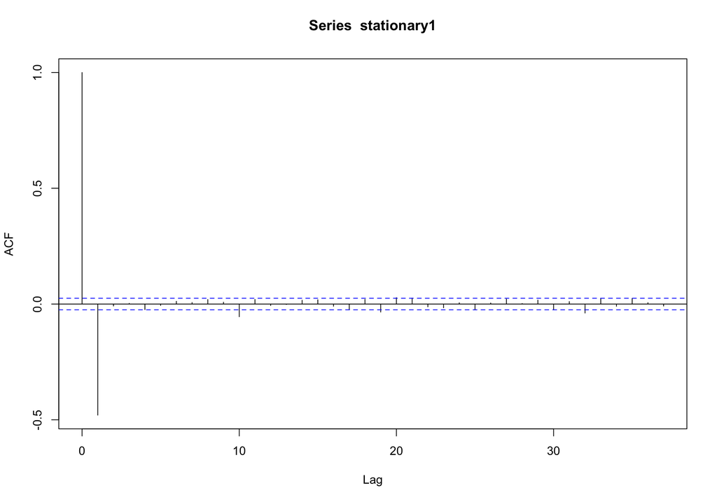

```r
acf(stationary1)
```